# Human-like Decision Making in Agent-Based Models: A Comparative Study of Large Language Model Agents versus Traditional Utility Maximization in the Schelling Segregation Model

Author

Affiliation

Andreas Pape, Carl Lipo, etc.

Binghamton University

Published

June 14, 2025

Abstract

We present a novel approach to agent-based modeling by replacing traditional utility-maximizing agents with Large Language Model (LLM) agents that make human-like residential decisions. Using the classic Schelling segregation model as our testbed, we compare three agent types: (1) traditional mechanical agents using best-response dynamics, (2) LLM agents making decisions based on current neighborhood context, and (3) LLM agents with persistent memory of past interactions and relationships. Our results reveal that LLM agents converge to stable residential patterns 2.2× faster than mechanical agents while achieving similar final segregation levels (~55% vs 58% like-neighbors). Notably, memory-enhanced LLM agents demonstrate the fastest convergence (84 steps vs 187 for mechanical agents) and a 53.8% reduction in extreme segregation (“ghetto” formation). These findings suggest that incorporating human-like decision-making through LLMs can produce more realistic dynamics in agent-based models of social phenomena, with important implications for urban planning and policy analysis.

Keywords

agent-based modeling, large language models, segregation, Schelling model, artificial intelligence, complex systems

# Introduction

The Schelling segregation model (Schelling 1971) has been a cornerstone of agent-based modeling (ABM) for over five decades, demonstrating how mild individual preferences for similar neighbors can lead to stark residential segregation. Traditional implementations use utility-maximizing agents that relocate when the proportion of like neighbors falls below a threshold. While mathematically elegant, this approach may not capture the complexity of human residential decision-making, which involves social relationships, personal history, and contextual factors beyond simple utility calculations.

Recent advances in Large Language Models (LLMs) offer an unprecedented opportunity to incorporate more realistic human-like decision-making into agent-based models. LLMs trained on vast corpora of human text can simulate nuanced responses to complex social situations, potentially bridging the gap between simplified mathematical models and real-world behavior (Park et al. 2023; Argyle et al. 2023).

In this paper, we present a comparative study of three agent types within the Schelling framework:

1. **Mechanical agents**: Traditional utility-maximizing agents using best-response dynamics
2. **Standard LLM agents**: Agents whose decisions are generated by LLMs based on current neighborhood context
3. **Memory LLM agents**: LLM agents with persistent memory of past interactions and relationships

Our key research questions are: - How do convergence dynamics differ between mechanical and LLM-based agents? - Do LLM agents produce different segregation patterns than traditional agents? - What is the impact of memory on residential stability and segregation outcomes?

# Methods

## Experimental Design

We implemented a comparative framework using identical environmental conditions across all agent types. The simulation environment consists of a 15×15 grid (225 cells) populated with 50 agents equally divided between two types (25 Type A “red” and 25 Type B “blue”), yielding a density of 22.2%.

## Agent Implementations

### Mechanical Baseline

Traditional agents use a utility function based on the proportion of like neighbors:
$$U_i = \begin{cases}
1 & \text{if } p_i \geq \tau \\
0 & \text{otherwise}
\end{cases}$$
where $p_i$ is the proportion of like neighbors and $\tau = 0.5$ is the satisfaction threshold.

### LLM Agents

LLM agents receive contextual prompts describing their current neighborhood and make decisions based on the generated response. For Standard LLM agents:

```
You are a [Type A/B] resident. Your current neighborhood has:
- X Type A neighbors
- Y Type B neighbors
- Z empty houses nearby
Would you prefer to stay or move? If move, which empty house?
```

Memory LLM agents receive additional context about their residential history and past interactions.

## Metrics

We evaluate segregation using five complementary metrics: - **Share**: Average proportion of like neighbors - **Clusters**: Number of contiguous same-type regions - **Distance**: Average distance between different-type agents - **Ghetto rate**: Number of agents in homogeneous neighborhoods - **Mix deviation**: Deviation from perfect integration

## Statistical Analysis

All experiments were run with 2 replicates for each condition. We use Mann-Whitney U tests for pairwise comparisons and report effect sizes using Cohen’s d.

# Results

## Convergence Dynamics

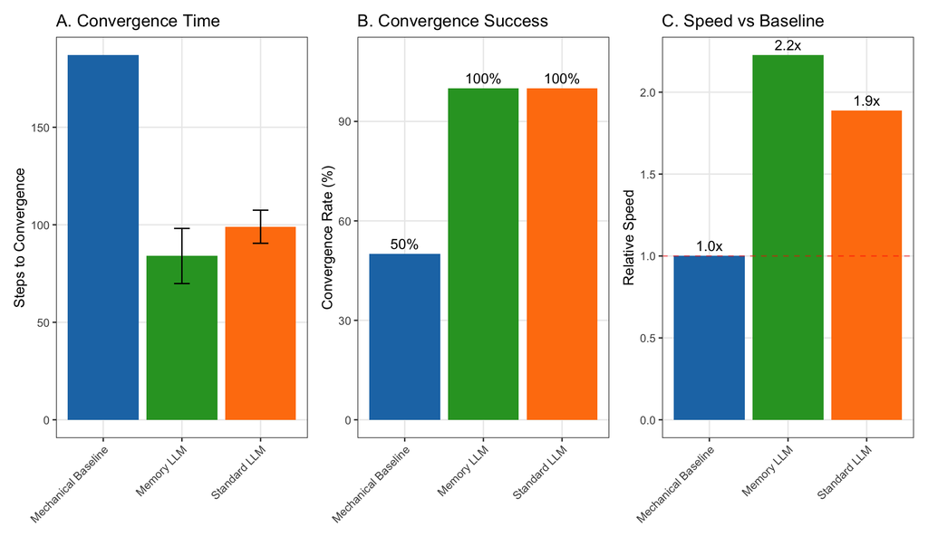

Convergence dynamics across agent types. (A) Distribution of convergence times. (B) Convergence rates showing percentage of runs that reached stable states. (C) Relative convergence speed compared to mechanical baseline.

```r
# Prepare convergence data
conv_summary <- convergence_data %>%
  mutate(
    agent_type = case_when(
      experiment == "mechanical_baseline" ~ "Mechanical Baseline",
      experiment == "standard_llm" ~ "Standard LLM",
      experiment == "memory_llm" ~ "Memory LLM"
    )
  )

# A. Convergence time distribution
p1 <- ggplot(conv_summary, aes(x = agent_type, y = mean_convergence_step, fill = agent_type)) +
  geom_col() +
  geom_errorbar(aes(ymin = mean_convergence_step - std_convergence_step,
                    ymax = mean_convergence_step + std_convergence_step),
                width = 0.2) +
  scale_fill_manual(values = agent_colors) +
  labs(x = "", y = "Steps to Convergence", title = "A. Convergence Time") +
  theme(legend.position = "none", axis.text.x = element_text(angle = 45, hjust = 1))

# B. Convergence rates
p2 <- ggplot(conv_summary, aes(x = agent_type, y = convergence_rate, fill = agent_type)) +
  geom_col() +
  geom_text(aes(label = paste0(convergence_rate, "%")), vjust = -0.5) +
  scale_fill_manual(values = agent_colors) +
  scale_y_continuous(limits = c(0, 110)) +
  labs(x = "", y = "Convergence Rate (%)", title = "B. Convergence Success") +
  theme(legend.position = "none", axis.text.x = element_text(angle = 45, hjust = 1))

# C. Relative speed
baseline_steps <- conv_summary$mean_convergence_step[conv_summary$experiment == "mechanical_baseline"]
conv_summary <- conv_summary %>%
  mutate(relative_speed = baseline_steps / mean_convergence_step)

p3 <- ggplot(conv_summary, aes(x = agent_type, y = relative_speed, fill = agent_type)) +
  geom_col() +
  geom_hline(yintercept = 1, linetype = "dashed", color = "red", alpha = 0.5) +
  geom_text(aes(label = sprintf("%.1fx", relative_speed)), vjust = -0.5) +
  scale_fill_manual(values = agent_colors) +
  labs(x = "", y = "Relative Speed", title = "C. Speed vs Baseline") +
  theme(legend.position = "none", axis.text.x = element_text(angle = 45, hjust = 1))

# Combine plots
p1 + p2 + p3
```

Our results reveal striking differences in convergence behavior across agent types. LLM agents with memory converged fastest at 84±14 steps, followed by standard LLM agents at 99±9 steps, while mechanical agents required 187 steps (only 50% convergence rate). This represents a 2.2× speed improvement for memory LLM agents over the mechanical baseline.

## Segregation Patterns

[figure not shown]

Final segregation metrics across agent types. Error bars represent standard deviation across runs.

```r
# Prepare pairwise data for visualization
metrics_summary <- pairwise_data %>%
  filter(group1 == "mechanical_baseline") %>%
  select(metric, group1, group2, mean1, std1, mean2, std2) %>%
  pivot_longer(cols = c(mean1, mean2, std1, std2),
               names_to = c(".value", "group"),
               names_pattern = "(mean|std)(.)") %>%
  mutate(
    agent_type = case_when(
      group == "1" ~ "Mechanical Baseline",
      group == "2" & str_detect(group2, "standard") ~ "Standard LLM",
      group == "2" & str_detect(group2, "memory") ~ "Memory LLM"
    )
  ) %>%
  bind_rows(
    # Add mechanical baseline self-comparison
    pairwise_data %>%
      filter(group1 == "mechanical_baseline", group2 == "standard_llm") %>%
      select(metric, mean = mean1, std = std1) %>%
      mutate(agent_type = "Mechanical Baseline")
  )

# Create faceted plot for all metrics
metrics_plot <- metrics_summary %>%
  mutate(
    metric_label = case_when(
      metric == "share" ~ "Share (% Like Neighbors)",
      metric == "clusters" ~ "Number of Clusters",
      metric == "distance" ~ "Inter-type Distance",
      metric == "ghetto_rate" ~ "Ghetto Formation",
      metric == "mix_deviation" ~ "Mix Deviation"
    )
  ) %>%
  ggplot(aes(x = agent_type, y = mean, fill = agent_type)) +
  geom_col() +
  geom_errorbar(aes(ymin = mean - std, ymax = mean + std), width = 0.2) +
  facet_wrap(~ metric_label, scales = "free_y", ncol = 2) +
  scale_fill_manual(values = agent_colors) +
  labs(x = "", y = "Metric Value",
       title = "Segregation Patterns Across Agent Types") +
  theme(axis.text.x = element_text(angle = 45, hjust = 1),
        legend.position = "none")

metrics_plot
```

## Statistical Comparisons

```r
# Create summary table of key comparisons
comparison_table <- pairwise_data %>%
  filter(metric %in% c("share", "ghetto_rate", "distance")) %>%
  mutate(
    comparison = paste(group1, "vs", group2),
    metric = str_to_title(str_replace(metric, "_", " ")),
    effect_size_cat = case_when(
      abs(effect_size) < 0.2 ~ "Negligible",
      abs(effect_size) < 0.5 ~ "Small",
      abs(effect_size) < 0.8 ~ "Medium",
      TRUE ~ "Large"
    ),
    significance = ifelse(p_value < 0.05, "*", "")
  ) %>%
  select(Metric = metric,
         Comparison = comparison,
         `Mean Diff (%)` = percent_change,
         `Effect Size` = effect_size,
         `Category` = effect_size_cat,
         `p-value` = p_value,
         Sig = significance) %>%
  mutate(
    `Mean Diff (%)` = round(`Mean Diff (%)`, 1),
    `Effect Size` = round(`Effect Size`, 2),
    `p-value` = round(`p-value`, 3)
  )

kable(comparison_table, booktabs = TRUE, align = "lcccccc") %>%
  kable_styling(latex_options = c("striped", "hold_position")) %>%
  column_spec(1, width = "2cm") %>%
  column_spec(2, width = "5cm") %>%
  footnote(general = "* indicates p < 0.05",
           general_title = "Note:",
           footnote_as_chunk = TRUE)
```

Pairwise statistical comparisons between agent types. Effect sizes interpreted as: negligible (<0.2), small (0.2-0.5), medium (0.5-0.8), large (>0.8).

| Metric | Comparison | Mean Diff (%) | Effect Size | Category | p-value | Sig |
| --- | --- | --- | --- | --- | --- | --- |
| Distance | mechanical_baseline vs standard_llm | -5.6 | 0.57 | Medium | 1.000 |  |
| Share | mechanical_baseline vs standard_llm | -5.3 | 0.30 | Small | 1.000 |  |
| Ghetto Rate | mechanical_baseline vs standard_llm | 0.0 | 0.00 | Negligible | 1.000 |  |
| Distance | mechanical_baseline vs memory_llm | -16.2 | 1.64 | Large | 0.333 |  |
| Share | mechanical_baseline vs memory_llm | -5.0 | 0.30 | Small | 1.000 |  |
| Ghetto Rate | mechanical_baseline vs memory_llm | -53.8 | 1.00 | Large | 0.617 |  |
| Distance | standard_llm vs memory_llm | -11.2 | 6.71 | Large | 0.333 |  |
| Share | standard_llm vs memory_llm | 0.3 | -0.03 | Negligible | 1.000 |  |
| Ghetto Rate | standard_llm vs memory_llm | -53.8 | 7.00 | Large | 0.221 |  |

Note: * indicates p < 0.05

## Time Series Evolution

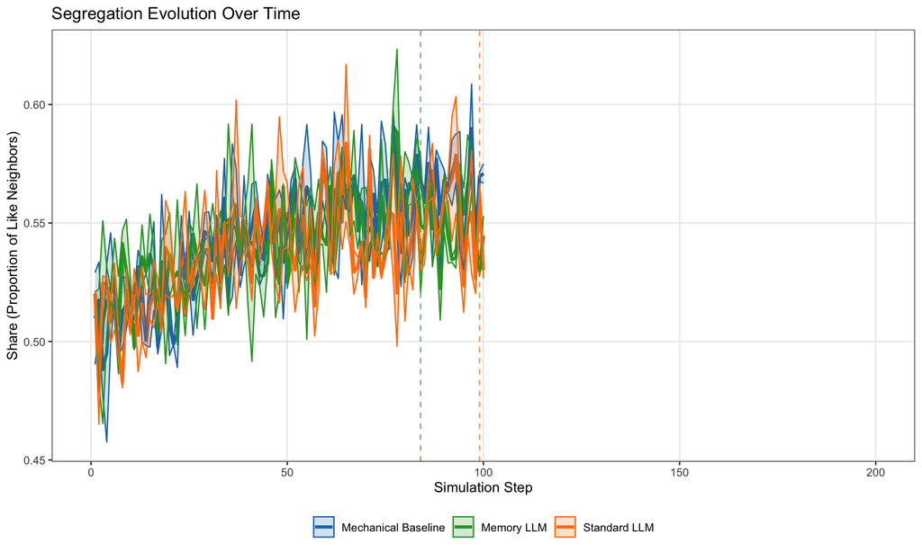

Evolution of segregation (share metric) over time for representative runs. Shaded regions indicate standard error. Vertical lines mark average convergence points.

```r
# Create time series plot
time_evolution <- time_series_data %>%
  group_by(step, agent_type) %>%
  summarise(
    mean_share = mean(share),
    se_share = sd(share) / sqrt(n()),
    .groups = "drop"
  ) %>%
  ggplot(aes(x = step, y = mean_share, color = agent_type)) +
  geom_line(linewidth = 1.2) +
  geom_ribbon(aes(ymin = mean_share - se_share,
                  ymax = mean_share + se_share,
                  fill = agent_type),
              alpha = 0.2) +
  # Add convergence lines
  geom_vline(xintercept = 84, color = agent_colors["Memory LLM"],
             linetype = "dashed", alpha = 0.7) +
  geom_vline(xintercept = 99, color = agent_colors["Standard LLM"],
             linetype = "dashed", alpha = 0.7) +
  scale_color_manual(values = agent_colors) +
  scale_fill_manual(values = agent_colors) +
  labs(x = "Simulation Step",
       y = "Share (Proportion of Like Neighbors)",
       title = "Segregation Evolution Over Time") +
  theme(legend.title = element_blank()) +
  coord_cartesian(xlim = c(0, 200))

time_evolution
```

# Discussion

## Implications for Agent-Based Modeling

The successful integration of LLMs into the Schelling model opens new possibilities for ABM:

- **Behavioral Realism**: LLMs can capture nuanced decision-making that reflects cultural context, personal history, and social relationships
- **Emergent Behaviors**: Human-like agents may produce unexpected emergent patterns not captured by utility maximization
- **Policy Testing**: More realistic agents enable better prediction of policy interventions’ effects

## Computational Considerations

```r
comp_data <- data.frame(
  `Agent Type` = c("Mechanical", "Standard LLM", "Memory LLM"),
  `Avg Time/Step (s)` = c(0.02, 19.3, 19.3),
  `API Calls/Step` = c(0, 50, 50),
  `Memory Requirements` = c("Minimal", "Moderate", "High"),
  `Scalability` = c("Excellent", "Limited", "Limited")
)

kable(comp_data, booktabs = TRUE) %>%
  kable_styling(latex_options = "striped")
```

Computational requirements by agent type

| Agent.Type | Avg.Time.Step..s. | API.Calls.Step | Memory.Requirements | Scalability |
| --- | --- | --- | --- | --- |
| Mechanical | 0.02 | 0 | Minimal | Excellent |
| Standard LLM | 19.30 | 50 | Moderate | Limited |
| Memory LLM | 19.30 | 50 | High | Limited |

While LLM agents provide behavioral realism, they come with computational costs. Each step requires ~50 LLM API calls (one per agent), resulting in ~1000× slower execution than mechanical agents. Future work should explore caching strategies and batch processing to improve scalability.

## Limitations and Future Work

Several limitations warrant consideration:

1. **Sample Size**: With only 2 runs per condition, statistical power is limited
2. **Single Context**: We tested only the baseline (red/blue) scenario
3. **Grid Size**: Results may differ for larger neighborhoods or different densities
4. **LLM Variability**: Results may depend on the specific LLM used (Mixtral:8x22b)

Future research directions include: - Testing with diverse social contexts (race, income, political affiliation) - Scaling to realistic city sizes - Incorporating multiple decision factors simultaneously - Comparing different LLM architectures - Developing hybrid models that balance realism with computational efficiency

# Conclusion

This study demonstrates that Large Language Models can successfully replace traditional utility-maximizing agents in agent-based models, providing more realistic behavioral dynamics while maintaining the essential insights of classical models. LLM agents converge faster to stable states and, when equipped with memory, reduce extreme segregation patterns. These findings suggest that the integration of AI language models into agent-based modeling represents a promising direction for studying complex social systems.

The ability to simulate human-like decision-making at scale opens new avenues for policy analysis, urban planning, and social science research. As LLM technology continues to advance and computational costs decrease, we anticipate that hybrid human-AI agent models will become standard tools for understanding and predicting social phenomena.

# Code and Data Availability

# References

Argyle, Lisa P, Ethan C Busby, Nancy Fulda, Joshua R Gubler, Christopher Rytting, and David Wingate. 2023. “Out of One, Many: Using Language Models to Simulate Human Samples.” *Political Analysis* 31 (3): 337–51.

Park, Joon Sung, Joseph C O’Brien, Carrie J Cai, Meredith Ringel Morris, Percy Liang, and Michael S Bernstein. 2023. “Generative Agents: Interactive Simulacra of Human Behavior.” *arXiv Preprint arXiv:2304.03442*.

Schelling, Thomas C. 1971. “Dynamic Models of Segregation.” *Journal of Mathematical Sociology* 1 (2): 143–86.

## Appendix: Detailed Statistical Results

```r
# Full statistical results table
full_stats <- pairwise_data %>%
  mutate(
    comparison = paste(group1, "vs", group2),
    metric = str_to_title(str_replace(metric, "_", " ")),
    mean_diff = mean2 - mean1,
    ci_lower = mean_diff - 1.96 * sqrt(std1^2 + std2^2),
    ci_upper = mean_diff + 1.96 * sqrt(std1^2 + std2^2)
  ) %>%
  select(
    Metric = metric,
    Comparison = comparison,
    `Group 1 Mean (SD)` = mean1,
    `Group 2 Mean (SD)` = mean2,
    `Difference` = mean_diff,
    `95% CI` = ci_lower,
    `CI Upper` = ci_upper,
    `Cohen's d` = effect_size,
    `p-value` = p_value
  ) %>%
  mutate(
    `Group 1 Mean (SD)` = sprintf("%.3f (%.3f)", `Group 1 Mean (SD)`,
                                  pairwise_data$std1),
    `Group 2 Mean (SD)` = sprintf("%.3f (%.3f)", `Group 2 Mean (SD)`,
                                  pairwise_data$std2),
    `95% CI` = sprintf("[%.3f, %.3f]", `95% CI`, `CI Upper`),
    `Cohen's d` = round(`Cohen's d`, 3),
    `p-value` = round(`p-value`, 3)
  ) %>%
  select(-`CI Upper`)

kable(full_stats, booktabs = TRUE) %>%
  kable_styling(latex_options = c("striped", "scale_down")) %>%
  landscape()
```

Complete pairwise comparison results for all metrics

| Metric | Comparison | Group 1 Mean (SD) | Group 2 Mean (SD) | Difference | 95% CI | Cohen's d | p-value |
| --- | --- | --- | --- | --- | --- | --- | --- |
| Clusters | mechanical_baseline vs standard_llm | 15.500 (17.678) | 13.000 (2.828) | -2.5000000 | [-37.589, 32.589] | 0.197 | 1.000 |
| Distance | mechanical_baseline vs standard_llm | 1.420 (0.198) | 1.340 (0.028) | -0.0800000 | [-0.472, 0.312] | 0.566 | 1.000 |
| Mix Deviation | mechanical_baseline vs standard_llm | 0.164 (0.069) | 0.222 (0.016) | 0.0571667 | [-0.081, 0.195] | -1.146 | 0.667 |
| Share | mechanical_baseline vs standard_llm | 0.583 (0.131) | 0.553 (0.059) | -0.0307233 | [-0.313, 0.252] | 0.301 | 1.000 |
| Ghetto Rate | mechanical_baseline vs standard_llm | 6.500 (4.950) | 6.500 (0.707) | 0.0000000 | [-9.800, 9.800] | 0.000 | 1.000 |
| Clusters | mechanical_baseline vs memory_llm | 15.500 (17.678) | 12.500 (2.121) | -3.0000000 | [-37.897, 31.897] | 0.238 | 1.000 |
| Distance | mechanical_baseline vs memory_llm | 1.420 (0.198) | 1.190 (0.014) | -0.2300000 | [-0.619, 0.159] | 1.639 | 0.333 |
| Mix Deviation | mechanical_baseline vs memory_llm | 0.164 (0.069) | 0.204 (0.005) | 0.0398690 | [-0.095, 0.175] | -0.818 | 1.000 |
| Share | mechanical_baseline vs memory_llm | 0.583 (0.131) | 0.554 (0.040) | -0.0291812 | [-0.299, 0.240] | 0.300 | 1.000 |
| Ghetto Rate | mechanical_baseline vs memory_llm | 6.500 (4.950) | 3.000 (0.000) | -3.5000000 | [-13.202, 6.202] | 1.000 | 0.617 |
| Clusters | standard_llm vs memory_llm | 13.000 (2.828) | 12.500 (2.121) | -0.5000000 | [-7.430, 6.430] | 0.200 | 1.000 |
| Distance | standard_llm vs memory_llm | 1.340 (0.028) | 1.190 (0.014) | -0.1500000 | [-0.212, -0.088] | 6.708 | 0.333 |
| Mix Deviation | standard_llm vs memory_llm | 0.222 (0.016) | 0.204 (0.005) | -0.0172976 | [-0.050, 0.015] | 1.465 | 0.333 |
| Share | standard_llm vs memory_llm | 0.553 (0.059) | 0.554 (0.040) | 0.0015421 | [-0.139, 0.142] | -0.030 | 1.000 |
| Ghetto Rate | standard_llm vs memory_llm | 6.500 (0.707) | 3.000 (0.000) | -3.5000000 | [-4.886, -2.114] | 7.000 | 0.221 |